# hRPTEC_DRW

Sem

2025-05-10

## Libraries

```r
library(ggplot2)
library(dplyr)
library(tibble)
library(purrr)
library(progressr)
library(WGCNA)
library(tidyr)
library(matrixStats)
```

## RPTEC Data

```r
data_dir <- "C:/Users/semde/Documents/BOO_Scripts/Data/RPTEC_TXG-MAPr"
adj_matrix   <- readRDS(file.path(data_dir, "RPTECTERT1_adjacencyMatrix.rds"))
expression_long   <- readRDS(file.path(data_dir, "expression_long.rds"))
module_definition        <- readRDS(file.path(data_dir, "module_definition.rds"))
module_annotation <- readRDS(file.path(data_dir, "module_annotation.rds"))
GRR_vs_eg_score          <- readRDS(file.path(data_dir, "GRR_vs_eg_score_RPTEC.rds"))
```

# Introduction

In this Rmd file, the Weighted Directed Random Walk will be performed on the RPTEC dataset.This involves performing a random walk over the network, where nodes present genes and edges present the directions of the network. The procedures described by (Hui et al, 2024) and (Liu et al, 2013) are followed as much as possible. However, they used predefined pathways and this project used co-expressed modules. So, some things will differ and it will be mentioned where it differs.

First, the directions of the network will be constructed based on the median(TOM) values of genes in a module, if media(TOM(gene A)) > median(TOM(gene B)) than A has an edge to B: A->B (represented as 1). This direction will be weighted by the Topological Overlap Matrix (TOM). *The original article uses predefined pathways for this.* Then, the directions will be reversed, because “a web page is important if other pages point to it” and therefore also genes (Liu et al, 2013). Also,an artificial ground node will be used, which is bidirectionally connected to every gene that has no connections to other genes and one directionally connected to every other gene. This is done to make sure that every node is connected and there are no 0-out of degree connections (Liu et al, 2013), making sure that the progation goes well and the walker converges. This results in the Weighted Graph $G$.

After that, the random walker will be performed:

$$W_{t+1} = (1 - r) A_{M_j} \cdot W_t + r W_0$$
Here, the $r$ represents the restart probability, set at 0.7 (Hui et al). This represents the chance to return to the initial weight vector ($W_0$), which represents the initial differential signal for each gene, based on biological and statistical significance: -log10(padj) * abs(Log2FC). *The original article used t-values, but the degrees of freedom are not known. So this score is proposed.*

$$W_0(g_i) = -\log_{10} \left( p_{\mathrm{adj}}(g_i) \right) \cdot \left|
\log_2 \mathrm{FC}(g_i) \right|$$

The $A_{Mj}$ represents the row normalized adjacency matrix of the Graph $G$. The $W_t$ vector represents the weight of the nodes (genes) at time $t$ and the $W_{t+1}$ vector represents the weight of the nodes (genes) at time $t+1$.

The recursive walker will be performed until the L1-norm ,the difference (delta), between $W_t$ and $W_{t+1}$ converges to $10^{–10}$ and this limit, the $W_{∞}$, will be obtained for each gene. The $W_{∞}$ of the ground node will be evenly distributed over the other genes in the module.

Afterwards, the module activty for module $M_j$ will be calculated using the following formula, only using genes that have a padj < 0.05 and an absolute log2fc greater than 1.0:

$$wDRW(M_j) = \frac{ \sum_{i=1}^{n_j} W_\infty(g_i) \cdot \log_2
\mathrm{FC}(g_i) }
{ \sqrt{n_j} \cdot \sqrt{ \sum_{i=1}^{n_j} \left( W_\infty(g_i)
\right)^2 } }$$

# Inspecting the adjacency matrix

First, the adj matrix will be inspected

```r
dim(adj_matrix)
```

```
## [1] 14325 14325
```

```r
head(adj_matrix[, 1:5])
```

```
##                  id_1     id_53947     id_51146      id_8086     id_65985
## id_1     1.000000e+00 6.095482e-28 2.741413e-09 2.326883e-10 7.283637e-21
## id_53947 6.095482e-28 1.000000e+00 3.147471e-08 3.727872e-08 8.908692e-17
## id_51146 2.741413e-09 3.147471e-08 1.000000e+00 4.431446e-09 8.083132e-14
## id_8086  2.326883e-10 3.727872e-08 4.431446e-09 1.000000e+00 2.725384e-13
## id_65985 7.283637e-21 8.908692e-17 8.083132e-14 2.725384e-13 1.000000e+00
## id_51166 4.337046e-07 1.836514e-11 7.918276e-16 3.759356e-13 5.807610e-16
```

```r
min(adj_matrix)
```

```
## [1] 1.970924e-95
```

```r
max(adj_matrix)
```

```
## [1] 1
```

```r
sum(adj_matrix[1, ])
```

```
## [1] 1.011303
```

```r
sum(adj_matrix[2, ])
```

```
## [1] 10.95521
```

adj matrix goes from ~0 to 1. and the x features have the same length as the y features, as expected due to it being an adjacency matrix. But rows are not normalized yet, this will have to be done for every module in the walker formula.

## Calculating the Topological Overlap Matrix (TOM)

The TOM will be calculated to later weight the directions of the graphs.

```r
#TOM <- TOMsimilarity(adj_matrix)
```

```r
#dimnames(TOM) <- dimnames(adj_matrix)
```

```r
TOM   <- readRDS(file.path(data_dir, "TOM_RPTEC.rds"))
```

```r
dim(TOM)
```

```
## [1] 14325 14325
```

```r
head(TOM[, 1:5])
```

```
##                  id_1     id_53947     id_51146      id_8086     id_65985
## id_1     1.000000e+00 3.952232e-07 1.013406e-08 7.554526e-09 4.823327e-09
## id_53947 3.952232e-07 1.000000e+00 1.929177e-06 2.193956e-05 2.047213e-06
## id_51146 1.013406e-08 1.929177e-06 1.000000e+00 5.480152e-09 6.353627e-09
## id_8086  7.554526e-09 2.193956e-05 5.480152e-09 1.000000e+00 3.311825e-09
## id_65985 4.823327e-09 2.047213e-06 6.353627e-09 3.311825e-09 1.000000e+00
## id_51166 4.431397e-07 5.450755e-06 1.168621e-08 1.770525e-08 4.733068e-09
```

As shown above, the TOM matrix calculation worked and the genes now have different values. Potentially, more topologically correct. This TOM will be used to weight the directions of the graph and to construct directions.

```r
#saveRDS(TOM, file = "TOM_RPTEC.rds")
```

# Removing NA Values and calculated padj from expression data

As discussed in the hRPTEC_eg.Rmd file. The padj values are not calculated and will be calculated. Also, NA values will be dropped after calculating padj.

```r
sum(is.na(expression_long$padj)) # Na values in padj
```

```
## [1] 552621
```

```r
expression_long$padj <- p.adjust(expression_long$pvalue, method = "BH")
sum(is.na(expression_long$padj))
```

```
## [1] 74278
```

```r
sum(is.na(expression_long$padj) & is.na(expression_long$log2fc))
```

```
## [1] 0
```

```r
expression_long_filtered <- expression_long %>%
  filter(!is.na(padj), !is.na(log2fc)) # Remove NA values for padj and log2FC
```

```r
sum(is.na(expression_long_filtered$padj))
```

```
## [1] 0
```

# Calculating W0 for the Directed Random Walker

The initial artical uses t-scores (Hui et al, 2024) for constructing the initial weight (W_0) of the walker, however the degrees of freedom are not known. So therefore, a different score will be used. For this the “walker score” will be used, which is proposed as the abs(Log2FC) * -log10(padj). To account for statistical significance and biological significance.

```r
expression_long_filtered$walker_score <- abs(expression_long_filtered$log2fc) *
                                         (-log10(expression_long_filtered$padj))
```

```r
sum(is.na(expression_long_filtered$walker_score))
```

```
## [1] 0
```

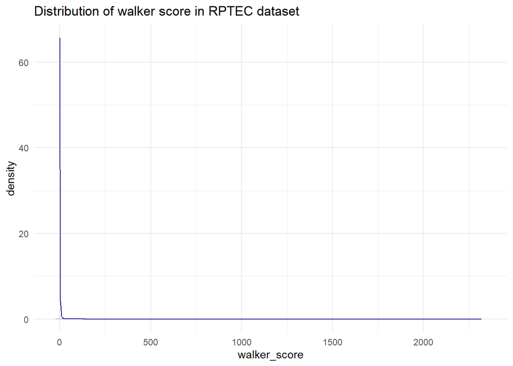

```r
ggplot(expression_long_filtered, aes(x = walker_score)) +
  geom_histogram(aes(y = ..density..), bins = 50, fill = "purple", alpha = 0.6) +
  geom_density(color = "darkblue") +
  theme_minimal() + labs(title = "Distribution of walker score in RPTEC dataset")
```

heavily skewed, but will be normalized in the activity calculation.

# Join the module_definition with the expression_long_filtered df

The module definition will be joined with the gene expression data to assign every gene to the corresponding module for later use in the random walk.

```r
expression_joined <- expression_long_filtered %>%
  left_join(module_definition %>% select(entrez_id, module_number), by = "entrez_id")
```

# Constructing the Directed Graph

To construct the Directed Graph for use in the Directed Random Walk. The median (TOM) scores will be used for genes in the same module. If median(TOM(gene A)) > median(TOM(gene B)) than A has an edge to B: A->B. Then the directions will be reversed: a webpage is important if other webpages point to it (Hui et al, 2024). This directed Graph will then be weighted by the TOM. Resulting in a weighted Directed Graph.

## Correlation EGs

No correlation EGs are given for the RPTEC dataset, so these will be calculated first. **this is not used anymore, but was before, so the chunks are still included**

```r
expression_cor_eg <- expression_joined %>%
  # Remove module 0, because this is removed in the GRR_vs_eg_score df
  filter(module_number != 0) %>%

  # Add eg_score per sample_id + module_number in expression df
  left_join(GRR_vs_eg_score, by = c("sample_id", "module_number")) %>%

  # calculate cor_eg per sample_id and module for every gene
  group_by(entrez_id, module_number) %>%
  mutate(
    cor_eg = abs(cor(log2fc, eg_score, method = "pearson", use = "pairwise.complete.obs"))
  ) %>%
  ungroup() %>%

  # Keep only relevant columns
  select(entrez_id, sample_id, module_number, log2fc, eg_score, cor_eg)
```

```r
sum(is.na(expression_cor_eg$cor_eg))
```

```
## [1] 0
```

## Adding all relevant columns to expression_cor_eg for the walker loop

```r
expression_cor_eg <- expression_cor_eg %>%
  left_join(
    expression_joined %>%
      select(entrez_id, sample_id, module_number, padj, walker_score),
    by = c("entrez_id", "sample_id", "module_number")
  )
```

## Calculating the Directed Graph

The directed graph will be calculated in the walker loop for each module+condition.

# Perform the walker on one module to learn how it works practically

## Defining the module and condition for the testing

```r
module_nr = 100
condition_id = "LU_HRPTECTERT1_SINGLE_CITRININ_T3_C3"
```

## Preparing the data for the condition and module

```r
# Subset the module

expr_sub <- expression_cor_eg %>%
  filter(module_number == module_nr, sample_id == condition_id)

genes_in_module <- expr_sub$entrez_id
cor_vec <- expr_sub$cor_eg
names(cor_vec) <- expr_sub$entrez_id
```

```r
genes_in_TOM <- intersect(genes_in_module, rownames(TOM))
cor_vec <- cor_vec[genes_in_TOM]
TOM_sub <- TOM[genes_in_TOM, genes_in_TOM]
```

## Defining the Directed Graph

Again, if median(TOM(A)) > median(TOM(B)) then edge: A -> B. However, these edges will be reverted: a gene is important if other genes point to it (Liu et al, 2013)

```r
TOM_medians <- apply(TOM_sub, 1, median, na.rm = TRUE)
```

```r
print(TOM_medians)
```

```
##    id_10061      id_211    id_10286     id_8892    id_54865    id_11103
## 0.017391294 0.005485547 0.003120431 0.010532170 0.005263061 0.001743016
##    id_55327     id_9221     id_5036    id_81572    id_80324    id_51605
## 0.001825233 0.007027430 0.013480864 0.006417734 0.009264301 0.027680862
```

```r
# Directional Graph based on TOM median
D <- outer(TOM_medians, TOM_medians, FUN = function(x, y) as.numeric(x < y))
rownames(D) <- colnames(D) <- names(TOM_medians)

W_directed <- D * TOM_sub # Weight the directions with the TOM
```

## Adding a ground node

A ground node will be added to ensure that the walker does not get stuck on a gene without outgoing edges. (Liu et al, 2013)

```r
genes <- rownames(W_directed)
ground_node <- "GROUND"
n <- length(genes)

# Maak empty matrix
W_plus <- matrix(0, nrow = n + 1, ncol = n + 1)
rownames(W_plus) <- colnames(W_plus) <- c(genes, ground_node)

# Add original matrix
W_plus[genes, genes] <- W_directed

# Add ground node to genes without outgoing edges
zero_rows <- which(rowSums(W_directed) == 0)
if (length(zero_rows) > 0) {
  W_plus[genes[zero_rows], ground_node] <- 1e-4  # This will be normalized to "1" later

  # Ground node has equal weight to every other gene in the module
  W_plus[ground_node, genes] <- 1
}

# Normalization of the matrix
diag(W_plus) <- 0
A <- W_plus / rowSums(W_plus)
```

```r
sum(A[1, ])
```

```
## [1] 1
```

```r
sum(A[2, ])
```

```
## [1] 1
```

```r
print(A)
```

```
##            id_10061     id_211    id_10286    id_8892    id_54865   id_11103
## id_10061 0.00000000 0.00000000 0.000000000 0.00000000 0.000000000 0.00000000
## id_211   0.21587852 0.00000000 0.000000000 0.05918407 0.000000000 0.00000000
## id_10286 0.18059801 0.13100047 0.000000000 0.05578375 0.018711562 0.00000000
## id_8892  0.22761516 0.00000000 0.000000000 0.00000000 0.000000000 0.00000000
## id_54865 0.25595971 0.12273673 0.000000000 0.03881742 0.000000000 0.00000000
## id_11103 0.04206644 0.01857593 0.012501303 0.05574055 0.004892965 0.00000000
## id_55327 0.08870428 0.04482117 0.007915681 0.14413055 0.012578213 0.00000000
## id_9221  0.12795443 0.00000000 0.000000000 0.19716879 0.000000000 0.00000000
## id_5036  0.40504807 0.00000000 0.000000000 0.00000000 0.000000000 0.00000000
## id_81572 0.34414673 0.00000000 0.000000000 0.08883500 0.000000000 0.00000000
## id_80324 0.22631814 0.00000000 0.000000000 0.23579958 0.000000000 0.00000000
## id_51605 0.00000000 0.00000000 0.000000000 0.00000000 0.000000000 0.00000000
## GROUND   0.08333333 0.08333333 0.083333333 0.08333333 0.083333333 0.08333333
##            id_55327    id_9221    id_5036   id_81572   id_80324   id_51605
## id_10061 0.00000000 0.00000000 0.00000000 0.00000000 0.00000000 1.00000000
## id_211   0.00000000 0.06991228 0.20689459 0.05149177 0.08325552 0.31338326
## id_10286 0.00000000 0.04579168 0.09735649 0.19928890 0.03308972 0.23837941
## id_8892  0.00000000 0.00000000 0.17836587 0.00000000 0.00000000 0.59401897
## id_54865 0.00000000 0.02902780 0.07458330 0.05121884 0.19423475 0.23342146
## id_11103 0.26394188 0.08808929 0.36640346 0.02246461 0.01203277 0.11329081
## id_55327 0.00000000 0.13604167 0.30814428 0.02915725 0.03330461 0.19520230
## id_9221  0.00000000 0.00000000 0.18622880 0.00000000 0.08195407 0.40669391
## id_5036  0.00000000 0.00000000 0.00000000 0.00000000 0.00000000 0.59495193
## id_81572 0.00000000 0.06665774 0.12352259 0.00000000 0.07037302 0.30646491
## id_80324 0.00000000 0.00000000 0.13078168 0.00000000 0.00000000 0.40710060
## id_51605 0.00000000 0.00000000 0.00000000 0.00000000 0.00000000 0.00000000
## GROUND   0.08333333 0.08333333 0.08333333 0.08333333 0.08333333 0.08333333
##          GROUND
## id_10061      0
## id_211        0
## id_10286      0
## id_8892       0
## id_54865      0
## id_11103      0
## id_55327      0
## id_9221       0
## id_5036       0
## id_81572      0
## id_80324      0
## id_51605      1
## GROUND        0
```

```r
print(expr_sub)
```

```
## # A tibble: 12 × 8
##    entrez_id sample_id         module_number  log2fc eg_score cor_eg[,1]    padj
##    <chr>     <chr>                     <dbl>   <dbl>    <dbl>      <dbl>   <dbl>
##  1 id_10061  LU_HRPTECTERT1_S…           100  0.612     0.203      0.877 3.96e-1
##  2 id_211    LU_HRPTECTERT1_S…           100  0.528     0.203      0.782 3.26e-1
##  3 id_10286  LU_HRPTECTERT1_S…           100  0.563     0.203      0.703 9.19e-2
##  4 id_8892   LU_HRPTECTERT1_S…           100 -1.02      0.203      0.818 8.58e-4
##  5 id_54865  LU_HRPTECTERT1_S…           100  0.196     0.203      0.733 1   e+0
##  6 id_11103  LU_HRPTECTERT1_S…           100 -0.381     0.203      0.650 2.81e-1
##  7 id_55327  LU_HRPTECTERT1_S…           100  0.137     0.203      0.652 8.83e-1
##  8 id_9221   LU_HRPTECTERT1_S…           100 -0.0201    0.203      0.816 1   e+0
##  9 id_5036   LU_HRPTECTERT1_S…           100  0.0559    0.203      0.881 1   e+0
## 10 id_81572  LU_HRPTECTERT1_S…           100  0.701     0.203      0.788 1.81e-3
## 11 id_80324  LU_HRPTECTERT1_S…           100 -0.187     0.203      0.789 9.73e-1
## 12 id_51605  LU_HRPTECTERT1_S…           100  0.238     0.203      0.928 8.22e-1
## # ℹ 1 more variable: walker_score <dbl>
```

The weighted directed matrix is correctly normalized. and directions are reversed.

## Defining the initial probability, based on the ‘walker score’

The initial probability will be assigned on the earlier calculated walker score.

```r
# Prepare the initial walker probability (W0) based on the proposed walker score.
  # Initialize W0 with all genes 0
  W0 <- rep(0, length(rownames(A)))
  names(W0) <- rownames(A)

  # Select only the walker score for significant genes
  W0_sig <- expr_sub %>%
    filter(entrez_id %in% rownames(A)) %>% # , padj < 0.05 was left out to reduce over estimation
    select(entrez_id, walker_score) %>%
    tibble::deframe()

  # Fill W0 only for significant genes
  W0[names(W0_sig)] <- abs(W0_sig)

  # Normalization
  W0 <- W0 / sum(W0)

  # Security: make sure the genes match
  stopifnot(all(names(W0) == rownames(A)))
```

```r
print(W0)
```

```
##     id_10061       id_211     id_10286      id_8892     id_54865     id_11103
## 0.0386371262 0.0403910782 0.0917744390 0.4893691993 0.0000000000 0.0329814221
##     id_55327      id_9221      id_5036     id_81572     id_80324     id_51605
## 0.0011592922 0.0000000000 0.0000000000 0.3021631650 0.0003424458 0.0031818322
##       GROUND
## 0.0000000000
```

```r
print(expr_sub$walker_score)
```

```
##  [1] 0.245872575 0.257034085 0.584019046 3.114167039 0.000000000 0.209881737
##  [7] 0.007377313 0.000000000 0.000000000 1.922856139 0.002179200 0.020248019
```

a higher walker score recieves a higher W0.

## Running the walker

```r
# Run random walk with restart

r <- 0.7
W_prev <- W0
convergence <- data.frame(iteration = 0, delta = NA)
W_all <- list(W_prev)

for (i in 1:1000) {
  W_new <- (1 - r) * A %*% W_prev + r * W0
  delta <- sum(abs(W_new - W_prev))
  convergence <- rbind(convergence, data.frame(iteration = i, delta = delta))
  W_all[[i + 1]] <- W_new
  if (delta < 1e-10) break
  W_prev <- W_new
}

W_inf <- as.numeric(W_new)
names(W_inf) <- rownames(A)
```

```r
print(summary(W_inf))
```

```
##     Min.  1st Qu.   Median     Mean  3rd Qu.     Max.
## 0.005165 0.021620 0.028029 0.068453 0.042174 0.346418
```

```r
print(W_inf)
```

```
##    id_10061      id_211    id_10286     id_8892    id_54865    id_11103
## 0.029667600 0.042173728 0.088265530 0.346417931 0.013902687 0.034666394
##    id_55327     id_9221     id_5036    id_81572    id_80324    id_51605
## 0.021620111 0.023673553 0.005164774 0.225869414 0.028029465 0.008738707
##      GROUND
## 0.021704747
```

Above shows the final weights of the walker.

### Distributing the final weight of the ground node

The final weight of the ground node will be evenly distributed across all other nodes.

```r
if ("GROUND" %in% names(W_inf)) {
  ground_mass <- W_inf["GROUND"]
  W_inf <- W_inf[names(W_inf) != "GROUND"]
  W_inf <- W_inf + ground_mass / length(W_inf)
}
```

```r
print(W_inf)
```

```
##    id_10061      id_211    id_10286     id_8892    id_54865    id_11103
## 0.031476329 0.043982457 0.090074259 0.348226660 0.015711416 0.036475123
##    id_55327     id_9221     id_5036    id_81572    id_80324    id_51605
## 0.023428840 0.025482282 0.006973503 0.227678143 0.029838194 0.010547436
```

## Visualizations

The walker output will be visualized to understand it better

### Visualization of the convergence

First the L1-norm, the difference between $W_t$ and $W_{t+1}$, will be visualized to assess how the walker converges.

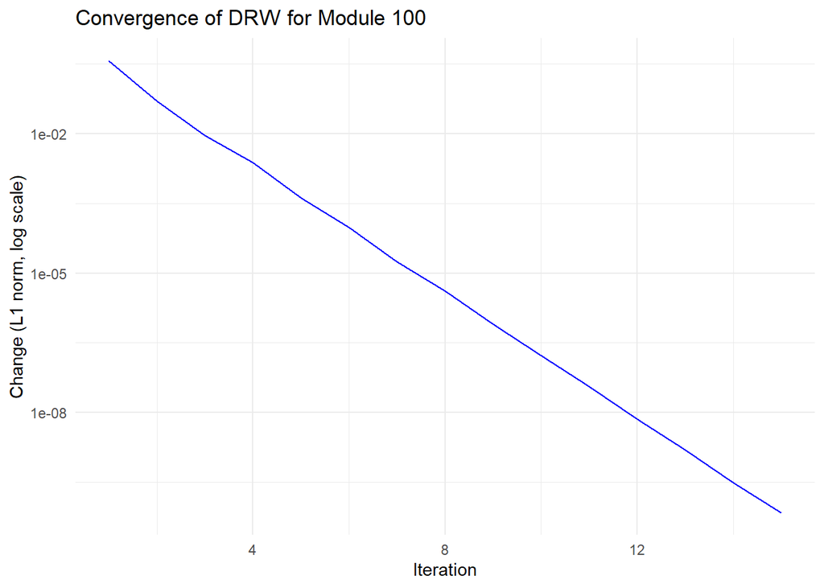

```r
# Visualize convergence

ggplot(convergence[-1, ], aes(x = iteration, y = delta)) +
  geom_line(color = "blue") +
  scale_y_log10() +
  labs(title = paste("Convergence of DRW for Module", module_nr),
       x = "Iteration", y = "Change (L1 norm, log scale)") +
  theme_minimal()
```

As shown above, the L1-norm decreases after iterations, making the recursive walker converge to the base case (L1-norm 10^-10).

### Visualizations of the weight vectors

Here the meanof the $W_0$ and $W_t$ vectors will be visualized.

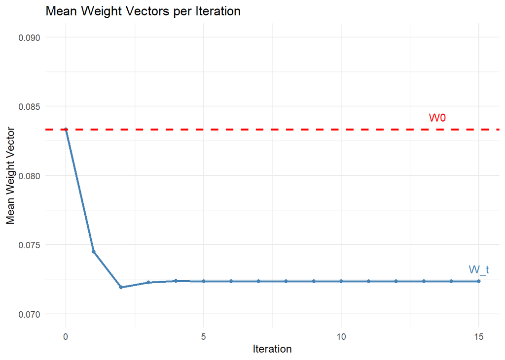

```r
# Preprocessing for visualization
walker_matrix <- do.call(cbind, W_all)
colnames(walker_matrix) <- paste0("iter_", seq_along(W_all) - 1)

# Remove ground node
walker_matrix <- walker_matrix[rownames(walker_matrix) != "GROUND", , drop = FALSE]

# Calculate mean scores of the W_t vector
mean_scores <- colMeans(walker_matrix, na.rm = TRUE)

# Mean of W0
mean_w0 <- mean_w0 <- mean(W0[names(W0) != "GROUND"])

# Create dataframe for visualization
mean_df <- tibble(
  iteration = seq_along(mean_scores) - 1,
  mean_score = mean_scores
)

last_iter <- max(mean_df$iteration)
last_score <- mean_df$mean_score[mean_df$iteration == last_iter]

ggplot(mean_df, aes(x = iteration, y = mean_score)) +
  geom_line(color = "steelblue", linewidth = 1) +
  geom_point(size = 1.5, color = "steelblue") +
  geom_hline(yintercept = mean_w0, color = "red", linetype = "dashed", linewidth = 1) +
  annotate("text", x = last_iter, y = last_score, label = "W_t", color = "steelblue", vjust = -1) +
  annotate("text", x = max(mean_df$iteration) * 0.9, y = mean_w0, label = "W0", color = "red", vjust = -1) +
  labs(title = "Mean Weight Vectors per Iteration",
       x = "Iteration", y = "Mean Weight Vector") +
  theme_minimal() +
  ylim(0.07, 0.09)
```

Above could be seen how the weight vectors change. It is shown that the W_t vector converges to a stable value, which is below the W0 vector in this case.

## Inferring pathway activity

```r
activity_df <- expression_joined %>%
  filter(sample_id == condition_id,
         entrez_id %in% names(W_inf),
         padj < 0.05, abs(log2fc) > 1.0) %>%
  select(entrez_id, log2fc) %>%
  mutate(W_inf = W_inf[entrez_id],
         term = W_inf * log2fc)

numerator <- sum(activity_df$term, na.rm = TRUE)
denominator <- sqrt(sum(activity_df$W_inf^2, na.rm = TRUE))
pathway_activity_score <- numerator / denominator
```

```r
# Output
cat("DRW pathway activity score for module", module_nr, "in condition", condition_id, ":\n")
```

```
## DRW pathway activity score for module 100 in condition LU_HRPTECTERT1_SINGLE_CITRININ_T3_C3 :
```

```r
print(pathway_activity_score)
```

```
## [1] -1.015586
```

```r
connectivity <- rowSums(TOM_sub)

print(
  activity_df %>%
    left_join(
      expression_joined %>%
        filter(sample_id == condition_id) %>%
        select(entrez_id, padj),
      by = "entrez_id"
    ) %>%
    mutate(connectivity = connectivity[entrez_id])
)
```

```
##    entrez_id    log2fc     W_inf       term         padj connectivity
##       <char>     <num>     <num>      <num>        <num>        <num>
## 1:   id_8892 -1.015586 0.3482267 -0.3536542 0.0008582744     1.137598
```

Above shows the genes that were used in the activity calculation. The connectivity column is the sum of the TOM rows.

# Perform the walker on the whole RPTEC dataset

The above applied logic was now incorporated in a function to loop over the whole dataset and calculate DRW scores.

## Function

This function will be called for every combination of module and condition in a loop. It follows the same procedure as the above calculation done “by hand”.

```r
compute_drw_score <- function(condition_id, module_nr, expression_df, TOM) {
  # Subset the expression dataframe for the specified module and sample
  expr_sub <- expression_df %>%
    filter(sample_id == condition_id, module_number == module_nr)

  if (nrow(expr_sub) == 0) {
    return(tibble(condition_id = condition_id, module_nr = module_nr, drw_score = 0))
  } # To ensure not crashing the function

  # Extract correlation vector
  cor_vec <- expr_sub$cor_eg
  names(cor_vec) <- expr_sub$entrez_id

  # Intersect genes with TOM matrix and create a subset
  genes_in_TOM <- intersect(expr_sub$entrez_id, rownames(TOM))
  cor_vec <- cor_vec[genes_in_TOM]
  TOM_sub <- TOM[genes_in_TOM, genes_in_TOM, drop = FALSE]

  if (length(genes_in_TOM) < 2) {
    return(tibble(condition_id = condition_id, module_nr = module_nr, drw_score = 0))
  } # To ensure not crashing the function

  # Create directed edges: gene B -> gene A if Median TOM(A) > median TOM(B) as explained above
  TOM_medians <- apply(TOM_sub, 1, median, na.rm = TRUE)

  # Directional Graph
  D <- outer(TOM_medians, TOM_medians, FUN = function(x, y) as.numeric(x < y))
  rownames(D) <- colnames(D) <- names(TOM_medians)

  # Weight the directed edges by the TOM
  W_directed <- D * TOM_sub

  # Add ground node to avoid 0 out of degree nodes
  genes <- rownames(W_directed)
  ground_node <- "GROUND"
  n <- length(genes)

  W_plus <- matrix(0, nrow = n + 1, ncol = n + 1)
  rownames(W_plus) <- colnames(W_plus) <- c(genes, ground_node)

  # Add original weighted adjacency to W_plus
  W_plus[genes, genes] <- W_directed

  # Add edges from ground node and to it if a row has no outgoing edges
  zero_rows <- which(rowSums(W_directed) == 0)
  if (length(zero_rows) > 0) {
    W_plus[genes[zero_rows], ground_node] <- 1e-4 # This will be normalized to 1 later
    W_plus[ground_node, genes] <- 1
  }

  # Normalize the matrix row-wise
  diag(W_plus) <- 0
  row_sums <- rowSums(W_plus)
  row_sums[row_sums == 0] <- 1e-10  # prevent division by zero (not possible if all goes well)
  A <- W_plus / row_sums

  # Prepare the initial walker probability (W0) based on the proposed walker score. To 'boost' the significant genes, they only get an innitial weight (W0), this is done to        reduce low DRW scores with high wGRR as this was shown in subset calculations

  # Initialize W0 with all genes 0
  W0 <- rep(0, length(rownames(A)))
  names(W0) <- rownames(A)

  # Select only the walker score for significant genes
  W0_sig <- expr_sub %>%
    filter(entrez_id %in% rownames(A)) %>% #, padj < 0.05
    select(entrez_id, walker_score) %>%
    tibble::deframe()

  # Fill W0 only for significant genes
  W0[names(W0_sig)] <- abs(W0_sig)

  # Security: no zeros
  if (sum(W0) == 0 || any(is.na(W0))) {
    return(tibble(condition_id = condition_id, module_nr = module_nr, drw_score = 0))
  }

  # Normalization
  W0 <- W0 / sum(W0)

  # Security: make sure the genes match
  stopifnot(all(names(W0) == rownames(A)))

  # Run random walk with restart
  r <- 0.7
  W_prev <- W0
  for (i in 1:1000) {
    W_new <- (1 - r) * A %*% W_prev + r * W0
    delta <- sum(abs(W_new - W_prev))
    if (is.na(delta)) return(NULL)
    if (delta < 1e-10) break
    W_prev <- W_new
  }

  W_inf <- as.numeric(W_new)
  names(W_inf) <- rownames(A)

  # Evenly redistribute W_inf of the ground to the other nodes
  if ("GROUND" %in% names(W_inf)) {
    ground_mass <- W_inf["GROUND"]
    W_inf <- W_inf[names(W_inf) != "GROUND"]
    W_inf <- W_inf + ground_mass / length(W_inf)
  }

  # Compute pathway activity using only genes with padj < 0.05
  activity_df <- expression_df %>%
    filter(sample_id == condition_id,
           module_number == module_nr,
           entrez_id %in% names(W_inf),
           padj < 0.05,
           abs(log2fc) > 1.0) %>%
    select(entrez_id, log2fc) %>%
    mutate(W_inf = W_inf[entrez_id],
           term = W_inf * log2fc)

  numerator <- sum(activity_df$term, na.rm = TRUE)
  denominator <- sqrt(sum(activity_df$W_inf^2, na.rm = TRUE))
  pathway_activity_score <- ifelse(denominator == 0, 0, numerator / denominator)

  tibble(condition_id = condition_id, module_nr = module_nr, drw_score = pathway_activity_score)
}
```

## Test the function

```r
drw_test_result <- compute_drw_score(
  condition_id = condition_id,
  module_nr = module_nr,
  expression_df = expression_cor_eg,
  TOM = TOM
)
```

## Inspect the test results

```r
# View the head of the results
print(head(drw_test_result))
```

```
## # A tibble: 1 × 3
##   condition_id                         module_nr drw_score
##   <chr>                                    <dbl>     <dbl>
## 1 LU_HRPTECTERT1_SINGLE_CITRININ_T3_C3       100     -1.02
```

This ‘test’ result is the same as the calculation done by hand. So now the goal is to loop over all the modules and conditions and calculate DRW scores with the function.

## Perform the DRW calculation on all the modules

All the unique combinations of sample_id and module_number will be filtered and later this will be looped over and the DRW functions will be applied

```r
# This chunk filters for all the unique combinations to loop over
module_samples <- expression_joined %>%
  filter(module_number != 0) %>%  # Exclude Module 0
  distinct(condition_id = sample_id, module_nr = module_number) #%>%
  #slice_tail(n = 2930)  # Keep only the last x combinations, for testing the function
```

```r
handlers("txtprogressbar") # this is to show the progress of the long calculation
```

This is a long calculation for the RPTEC dataset and was performed on ALICE.

```r
with_progress({
  p <- progressor(steps = nrow(module_samples))

  drw_scores <- map_dfr(
    1:nrow(module_samples),
    function(i) {
      row <- module_samples[i, ]
      p()

        tryCatch({
        # Casting to the right data structures to be sure
        cond_id <- as.character(row$condition_id)
        mod_nr <- as.integer(row$module_nr)

        compute_drw_score(
          condition_id = cond_id,
          module_nr = mod_nr,
          expression_df = expression_cor_eg,
          TOM = TOM
        )

      }, error = function(e) {
        message("Error With ", row$condition_id, " × ", row$module_nr, ": ", e$message)
        return(NULL)
      })
    }
  )
})
```

```r
drw_scores          <- readRDS(file.path(data_dir, "drw_scores_RPTEC_r0.7.rds")) # reading the drw_scores
```

```r
print(head(drw_scores))
```

```
## # A tibble: 6 × 5
##   condition_id                        module_nr drw_score module_size drw_zscore
##   <chr>                                   <dbl>     <dbl>       <dbl>      <dbl>
## 1 LU_HRPTECTERT1_SINGLE_ACTIVINA_T1_…        17         0         129          0
## 2 LU_HRPTECTERT1_SINGLE_ACTIVINA_T1_…        43         0          29          0
## 3 LU_HRPTECTERT1_SINGLE_ACTIVINA_T1_…       112         0          11          0
## 4 LU_HRPTECTERT1_SINGLE_ACTIVINA_T1_…        25         0          85          0
## 5 LU_HRPTECTERT1_SINGLE_ACTIVINA_T1_…        24         0          95          0
## 6 LU_HRPTECTERT1_SINGLE_ACTIVINA_T1_…         9         0         366          0
```

```r
print(tail(drw_scores))
```

```
## # A tibble: 6 × 5
##   condition_id                        module_nr drw_score module_size drw_zscore
##   <chr>                                   <dbl>     <dbl>       <dbl>      <dbl>
## 1 LU_HRPTECTERT1_SINGLE_ZOLENDRONICA…       269      2.05           6      0.837
## 2 LU_HRPTECTERT1_SINGLE_ZOLENDRONICA…       270      0              6      0
## 3 LU_HRPTECTERT1_SINGLE_ZOLENDRONICA…       243      1.74           7      0.656
## 4 LU_HRPTECTERT1_SINGLE_ZOLENDRONICA…       271     -3.76           6     -1.53
## 5 LU_HRPTECTERT1_SINGLE_ZOLENDRONICA…       272      2.14           6      0.874
## 6 LU_HRPTECTERT1_SINGLE_ZOLENDRONICA…       244     -2.61           7     -0.986
```

```r
sum(is.na(drw_scores$drw_score))
```

```
## [1] 0
```

No NA values

### Normalization

The DRW scores will be normalized for their module_size and called the drw_zscore (it is not really a z-score but this is for simplification)

```r
#drw_scores <- drw_scores %>%
 # left_join(
  #  GRR_vs_eg_score %>% select(sample_id, module_number, module_size),
   # by = c("condition_id" = "sample_id", "module_nr" = "module_number")
  #) %>%
  #mutate(
   # drw_zscore = drw_score / module_size
  #)
```

```r
sum(is.na(drw_scores$drw_zscore))
```

```
## [1] 0
```

```r
#saveRDS(drw_scores, file = "drw_scores_RPTEC_directed.rds") # saving the drw_scores
```

No NA values

# Evaluate the DRW scores on the RPTEC with the GRR and wGRR metric

The DRW scores will be evaluated on the Gene Response Rate and Weighted Gene Response Rate (wGRR) metric, which is proposed as an evaluation metric for the topological activation of every unique combination of condition and module. The GRR and wGRR are presented as the following formulas:

$$\mathrm{GRR}(M_j) = \frac{ \displaystyle \sum_{i=1}^{n_j} \left( |\log_2
\mathrm{FC}_i| > 1.0 \,\wedge\, p_{\mathrm{adj},i} < 0.05 \right)}
{ n_j }$$

$$\mathrm{wGRR}(M_j) = \frac{ \displaystyle \sum_{i=1}^{n_j} \left(
|\log_2 \mathrm{FC}_i| > 1.0 \,\wedge\, p_{\mathrm{adj},i} < 0.05
\right) \cdot \mathrm{median(TOM)}_i }{ \sum_{i=1}^{n_j}
\mathrm{median(TOM)}_i }$$
The GRR represents the proportion of significantly expressed genes in a module (abs log2fc > 1.0 and padj < 0.05) and the wGRR weighs this proportion by the median(TOM) of a gene within a module.

## GRR

```r
GRR_vs_DRW <- GRR_vs_eg_score %>%
  left_join(
    drw_scores %>%
      select(-module_size),
    by = c("sample_id" = "condition_id", "module_number" = "module_nr")
  )
```

## wGRR

### Median TOM

```r
get_module_relative_tom <- function(TOM, gene_module_df) {
  gene_module_df <- gene_module_df %>%
    distinct(entrez_id, module_number) %>%
    filter(entrez_id %in% rownames(TOM))

  gene_module_df %>%
    group_by(module_number) %>%
    group_modify(~ {
      genes <- .x$entrez_id
      sub_tom <- TOM[genes, genes, drop = FALSE]
      diag(sub_tom) <- NA

      tom_median <- matrixStats::rowMedians(sub_tom, na.rm = TRUE)
      total_median <- sum(tom_median, na.rm = TRUE)
      tom_relative <- tom_median / total_median

      tibble(
        entrez_id = genes,
        tom_median = tom_median,
        tom_relative = tom_relative
      )
    }) %>%
    ungroup()
}
```

```r
# Calculate TOM weights
tom_weights <- get_module_relative_tom(TOM, expression_cor_eg)
```

```r
# Join with expression
expression_cor_eg <- expression_cor_eg %>%
  left_join(tom_weights, by = c("entrez_id", "module_number")) %>%
  mutate(tom_median = as.numeric(tom_median), tom_relative = as.numeric(tom_relative))
```

### Calculating the wGRR

```r
weighted_grr_df <- expression_cor_eg %>%
  mutate(is_significant = sign(log2fc) * as.numeric(abs(log2fc) > 1 & padj < 0.05)) %>%
  group_by(sample_id, module_number) %>%
  summarise(
    wGRR = sum(is_significant * tom_relative, na.rm = TRUE),
    GRR = sum(is_significant, na.rm = TRUE),
    .groups = "drop"
  )
```

```r
# Join the calculated wGRR with GRR_vs_DRW
GRR_vs_DRW <- GRR_vs_DRW %>%
  select(-GRR) %>%
  left_join(weighted_grr_df, by = c("sample_id", "module_number")) %>%
  mutate(wGRR = wGRR, GRR = GRR / module_size)  #/ module_size
```

```r
sum(is.na(GRR_vs_DRW$wGRR))
```

```
## [1] 0
```

```r
sum(is.na(GRR_vs_DRW$GRR))
```

```
## [1] 0
```

```r
min(GRR_vs_DRW$wGRR)
```

```
## [1] -1
```

```r
min(GRR_vs_DRW$GRR)
```

```
## [1] -1
```

```r
#saveRDS(GRR_vs_DRW, file = "GRR_vs_DRW_cor_eg.rds") # saving the wGRR for other RPTEC scoring methods
```

## Density plots of GRR, wGRR and DRW score

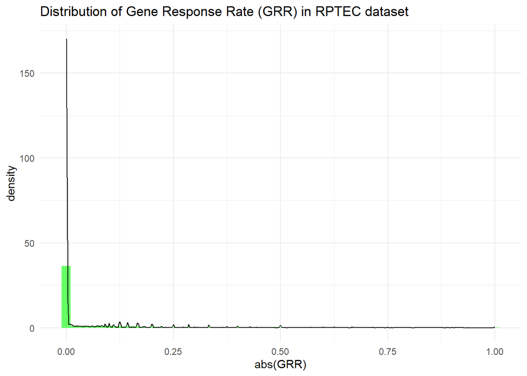

```r
ggplot(GRR_vs_DRW, aes(x = abs(GRR))) +
  geom_histogram(aes(y = ..density..), bins = 50, fill = "green", alpha = 0.6) +
  geom_density(color = "black") +
  theme_minimal() + labs(title = "Distribution of Gene Response Rate (GRR) in RPTEC dataset")
```

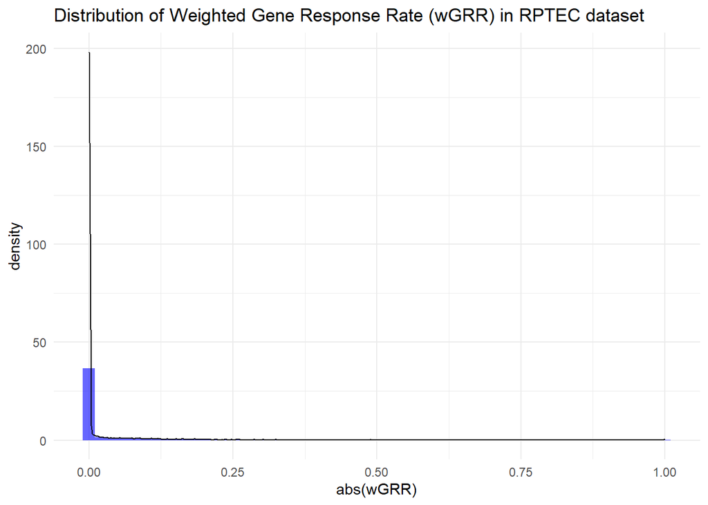

```r
ggplot(GRR_vs_DRW, aes(x = abs(wGRR))) +
  geom_histogram(aes(y = ..density..), bins = 50, fill = "blue", alpha = 0.6) +
  geom_density(color = "black") +
  theme_minimal() + labs(title = "Distribution of Weighted Gene Response Rate (wGRR) in RPTEC dataset")
```

Both abs(wGRR) and abs(GRR) log distributed

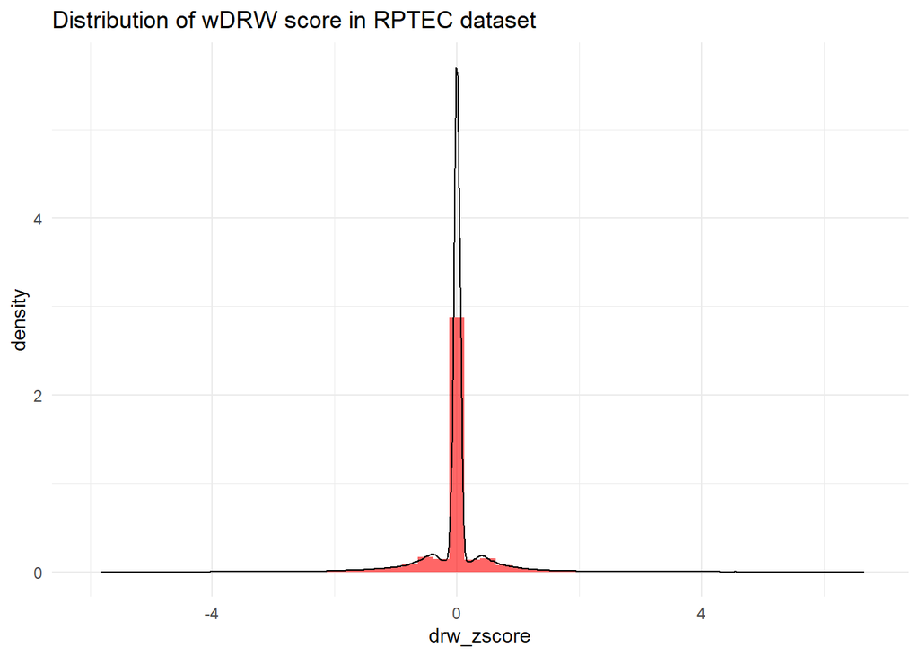

```r
ggplot(GRR_vs_DRW, aes(x = drw_zscore)) +
  geom_histogram(aes(y = ..density..), bins = 50, fill = "red", alpha = 0.6) +
  geom_density(color = "black") +
  theme_minimal() + labs(title = "Distribution of wDRW score in RPTEC dataset")
```

# Fitting wDRW vs GRR and wGRR using binomial GLMS

## Visualize GRR and wGRR vs DRW score with a linear fit

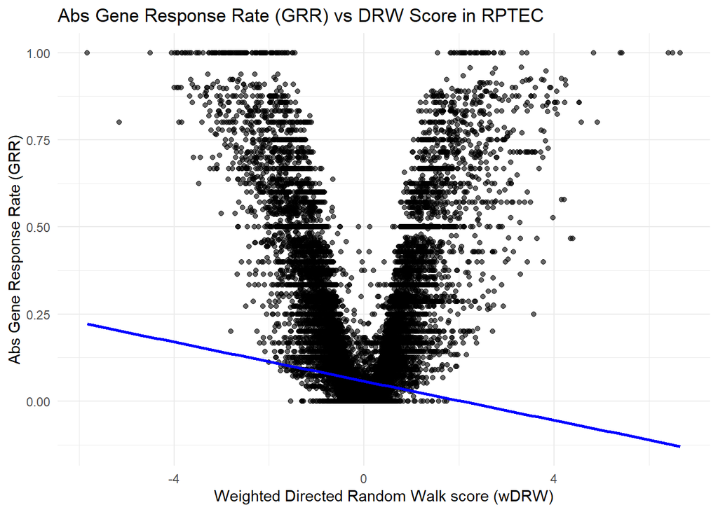

```r
ggplot(GRR_vs_DRW, aes(x = drw_zscore, y = abs(GRR))) +
  geom_point(alpha = 0.6) +
  geom_smooth(method = "lm", se = FALSE, color = "blue") +
  theme_minimal() +
  labs(
    title = "Abs Gene Response Rate (GRR) vs DRW Score in RPTEC",
    x = "Weighted Directed Random Walk score (wDRW)",
    y = "Abs Gene Response Rate (GRR)"
  )
```

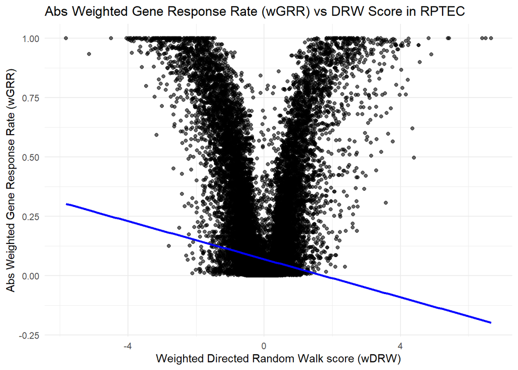

```r
ggplot(GRR_vs_DRW, aes(x = drw_zscore, y = abs(wGRR))) +
  geom_point(alpha = 0.6) +
  geom_smooth(method = "lm", se = FALSE, color = "blue") +
  theme_minimal() +
  labs(
    title = "Abs Weighted Gene Response Rate (wGRR) vs DRW Score in RPTEC",
    x = "Weighted Directed Random Walk score (wDRW)",
    y = "Abs Weighted Gene Response Rate (wGRR)"
  )
```

The linear fit does not fit the data well visually, so a binomial glm will be fitted and outliers will be calculated from this fit.

## Binomial Generalized Linear Model (GLM): GRR vs DRW

```r
glm_data <- GRR_vs_DRW %>%
  filter(!is.na(GRR), !is.na(drw_zscore)) # This filtering was performed as the function was first tested on a subset, but the filtering is irrelevant for the whole dataset as there are no NAs
```

```r
glm_fit <- glm(
  abs(GRR) ~ abs(drw_zscore), # absolute because of binomial
  data = glm_data,
  family = quasibinomial(link = "logit") # quasibinomial as the wGRR is a proportion multiplied by a continuous variable, the median(TOM)
)
```

```r
# Make predictions and residuals
glm_predictions <- predict(glm_fit, type = "response")
glm_dev_resid <- residuals(glm_fit, type = "deviance")

# Combine into a new dataframe
GRR_glm_fit_df <- glm_data %>%
  mutate(
    fitted_GRR = glm_predictions,
    GRR_resid = abs(GRR) - fitted_GRR,
    dev_resid = glm_dev_resid
  )
```

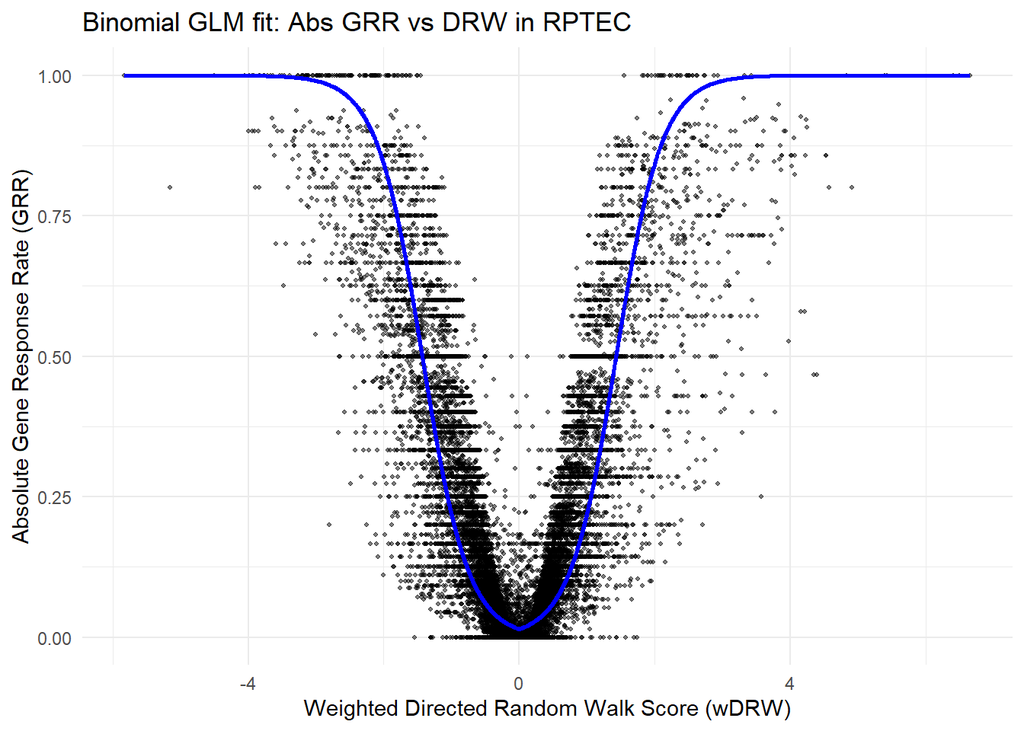

```r
ggplot(GRR_glm_fit_df, aes(x = drw_zscore, y = abs(GRR))) +
  geom_point(alpha = 0.5, size = 0.8) +
  geom_line(aes(y = fitted_GRR), color = "blue", size = 1) +
  theme_minimal() +
  labs(
    title = "Binomial GLM fit: Abs GRR vs DRW in RPTEC",
    x = "Weighted Directed Random Walk Score (wDRW)",
    y = "Absolute Gene Response Rate (GRR)"
  )
```

Visually, there are less outlying points using the DRW score than using the abs Eigengene score.

```r
summary(glm_fit)
```

```
##
## Call:
## glm(formula = abs(GRR) ~ abs(drw_zscore), family = quasibinomial(link = "logit"),
##     data = glm_data)
##
## Coefficients:
##                 Estimate Std. Error t value Pr(>|t|)
## (Intercept)     -4.21999    0.01526  -276.5   <2e-16 ***
## abs(drw_zscore)  2.94858    0.01684   175.1   <2e-16 ***
## ---
## Signif. codes:  0 '***' 0.001 '**' 0.01 '*' 0.05 '.' 0.1 ' ' 1
##
## (Dispersion parameter for quasibinomial family taken to be 0.2549523)
##
##     Null deviance: 16593.3  on 72155  degrees of freedom
## Residual deviance:  4438.5  on 72154  degrees of freedom
## AIC: NA
##
## Number of Fisher Scoring iterations: 7
```

Good fit

### significant outliers

For each module and sample, we compare the observed number of significant genes to the expected number based on the binomial GLM, and calculate a two-sided z-score and p-value using the binomial standard error. By doing this, the significant outlying modules from the glm fit are identified.

```r
GRR_glm_fit_df <- GRR_glm_fit_df %>%
  mutate(
    se_fit = sqrt(fitted_GRR * (1 - fitted_GRR) / module_size),
    z_score = GRR_resid / se_fit,
    p_value = 2 * pnorm(-abs(z_score))  # two-sided test
  )
```

```r
GRR_glm_fit_df <- GRR_glm_fit_df %>%
  mutate(
    outlier = p_value < 0.05,
    outlier_direction = case_when(
      outlier & z_score > 0 ~ "Above fit",
      outlier & z_score < 0 ~ "Below fit",
      TRUE ~ "Not significant"
    )
  )
```

```r
GRR_glm_fit_df <- GRR_glm_fit_df %>%
  mutate(module = paste0("hRPTECTERT1_", module_number)) %>%
  left_join(module_annotation, by = "module")
```

```r
sum(GRR_glm_fit_df$outlier, na.rm = TRUE)
```

```
## [1] 4914
```

There are 4914 outliers found. This is less than the eg score.

```r
total_modules_all <- GRR_glm_fit_df %>%
  filter(module_number != 0) %>%
  summarise(n = n_distinct(module_number)) %>%
  pull(n) # for normalization
```

```r
total_conditions_all <- GRR_glm_fit_df %>%
  filter(module_number != 0) %>%
  summarise(n = n_distinct(sample_id)) %>%
  pull(n) # for normalization
```

```r
# Make a summarizing df for comparing with other datasets and scoring algorithms
outlier_density <- GRR_glm_fit_df %>%
  filter(outlier, module_number != 0) %>%
  group_by(outlier_direction) %>%
  summarise(
    total_outliers = n(),
    .groups = "drop"
  ) %>%
  bind_rows(
    tibble(
      outlier_direction = "Total",
      total_outliers = sum(.$total_outliers)
    )
  ) %>%
  mutate(
    total_modules = total_modules_all,
    total_conditions = total_conditions_all,
    density = total_outliers / (total_modules * total_conditions)
  )
```

```r
print(outlier_density)
```

```
## # A tibble: 3 × 5
##   outlier_direction total_outliers total_modules total_conditions density
##   <chr>                      <int>         <int>            <int>   <dbl>
## 1 Above fit                   2328           291              248  0.0323
## 2 Below fit                   2586           291              248  0.0358
## 3 Total                       4914           291              248  0.0681
```

Above shows the outlier density. n outliers / (n conditions * n modules)

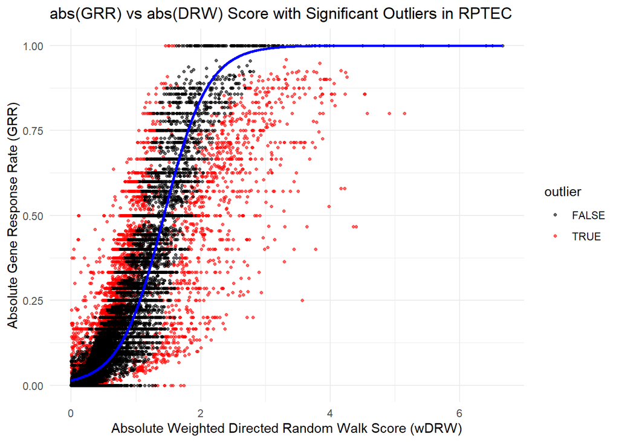

```r
ggplot(GRR_glm_fit_df, aes(x = abs(drw_zscore), y = abs(GRR))) +
  geom_point(aes(color = outlier), alpha = 0.6, size = 0.9) +
  geom_line(aes(y = fitted_GRR), color = "blue", size = 1) +
  scale_color_manual(values = c("black", "red")) +
  theme_minimal() +
  labs(
    title = "abs(GRR) vs abs(DRW) Score with Significant Outliers in RPTEC",
    x = "Absolute Weighted Directed Random Walk Score (wDRW)",
    y = "Absolute Gene Response Rate (GRR)"
  )
```

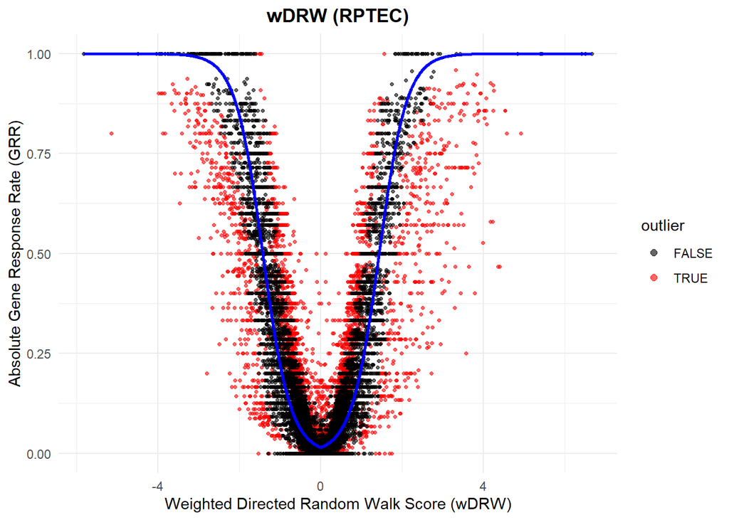

```r
ggplot(GRR_glm_fit_df, aes(x = drw_zscore, y = abs(GRR))) +
  geom_point(aes(color = outlier), alpha = 0.6, size = 0.9) +
  geom_line(aes(y = fitted_GRR), color = "blue", size = 1) +
  scale_color_manual(values = c("black", "red")) +
  theme_minimal() + theme(plot.title = element_text(hjust = 0.5, face = "bold")) +
  guides(color = guide_legend(override.aes = list(size = 2))) +
  labs(
    title = "wDRW (RPTEC)",
    x = "Weighted Directed Random Walk Score (wDRW)",
    y = "Absolute Gene Response Rate (GRR)"
  )
```

This fit shows, visually, less over and under quantification compared to the EG. especially the high EG scores (overquantification) with 0 gene responses are not present. Overall, this scoring shows less randomness than the eg scoring method on the proposed evaluation metric.

## Binomial Generalized Linear Model (GLM): wGRR vs DRW

```r
glm_data <- GRR_vs_DRW %>%
  filter(!is.na(wGRR), !is.na(drw_zscore)) # This filtering was performed as the function was first tested on a subset, but the filtering is irrelevant for the whole dataset as there are no NAs
```

```r
glm_fit <- glm(
  abs(wGRR) ~ abs(drw_zscore),
  data = glm_data,
  family = quasibinomial(link = "logit") # quasibinomial as the wGRR is a proportion multiplied by a continuous variable, the cor_eg.
)
```

```r
# Make predictions and residuals
glm_predictions <- predict(glm_fit, type = "response")
glm_dev_resid <- residuals(glm_fit, type = "deviance")

# Combine into a new dataframe
GRR_glm_fit_df <- glm_data %>%
  mutate(
    fitted_wGRR = glm_predictions,
    wGRR_resid = abs(wGRR) - fitted_wGRR,
    dev_resid = glm_dev_resid
  )
```

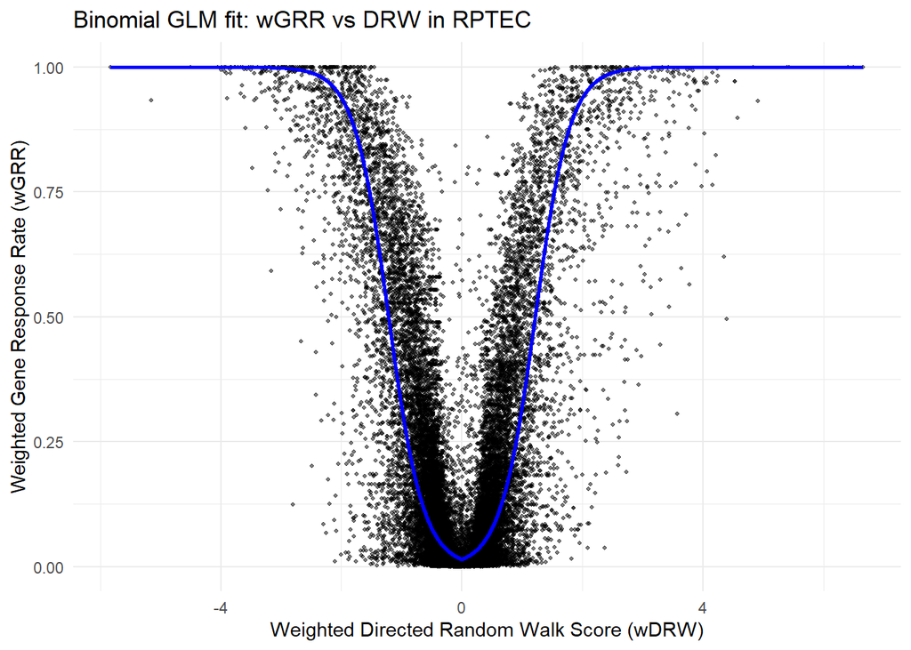

```r
ggplot(GRR_glm_fit_df, aes(x = drw_zscore, y = abs(wGRR))) +
  geom_point(alpha = 0.5, size = 0.8) +
  geom_line(aes(y = fitted_wGRR), color = "blue", size = 1) +
  theme_minimal() +
  labs(
    title = "Binomial GLM fit: wGRR vs DRW in RPTEC",
    x = "Weighted Directed Random Walk Score (wDRW)",
    y = "Weighted Gene Response Rate (wGRR)"
  )
```

Visually, there are less outlying points using the DRW score than using the abs Eigengene score.

```r
summary(glm_fit)
```

```
##
## Call:
## glm(formula = abs(wGRR) ~ abs(drw_zscore), family = quasibinomial(link = "logit"),
##     data = glm_data)
##
## Coefficients:
##                 Estimate Std. Error t value Pr(>|t|)
## (Intercept)     -4.22714    0.02667  -158.5   <2e-16 ***
## abs(drw_zscore)  3.47393    0.03226   107.7   <2e-16 ***
## ---
## Signif. codes:  0 '***' 0.001 '**' 0.01 '*' 0.05 '.' 0.1 ' ' 1
##
## (Dispersion parameter for quasibinomial family taken to be 0.7743767)
##
##     Null deviance: 22190.2  on 72155  degrees of freedom
## Residual deviance:  6289.3  on 72154  degrees of freedom
## AIC: NA
##
## Number of Fisher Scoring iterations: 7
```

Good fit

### significant outliers

For each module and sample, we compare the observed number of significant genes to the expected number based on the binomial GLM, and calculate a two-sided z-score and p-value using the binomial standard error. By doing this, the significant outlying modules from the glm fit are identified.

```r
GRR_glm_fit_df <- GRR_glm_fit_df %>%
  mutate(
    se_fit = sqrt(fitted_wGRR * (1 - fitted_wGRR) / module_size),
    z_score = wGRR_resid / se_fit,
    p_value = 2 * pnorm(-abs(z_score))  # two-sided test
  )
```

```r
GRR_glm_fit_df <- GRR_glm_fit_df %>%
  mutate(
    outlier = p_value < 0.05,
    outlier_direction = case_when(
      outlier & z_score > 0 ~ "Above fit",
      outlier & z_score < 0 ~ "Below fit",
      TRUE ~ "Not significant"
    )
  )
```

```r
GRR_glm_fit_df <- GRR_glm_fit_df %>%
  filter(!is.na(module_number)) %>%
  mutate(module = paste0("hRPTECTERT1_", module_number)) %>%
  left_join(module_annotation, by = "module")
```

```r
sum(GRR_glm_fit_df$outlier, na.rm = TRUE)
```

```
## [1] 6998
```

There are 6998 outliers found. This is less than the eg score.

```r
total_modules_all <- GRR_glm_fit_df %>%
  filter(module_number != 0) %>%
  summarise(n = n_distinct(module_number)) %>%
  pull(n) # for normalization
```

```r
total_conditions_all <- GRR_glm_fit_df %>%
  filter(module_number != 0) %>%
  summarise(n = n_distinct(sample_id)) %>%
  pull(n) # for normalization
```

```r
# Make a summarizing df for comparing with other datasets and scoring algorithms
outlier_density <- GRR_glm_fit_df %>%
  filter(outlier, module_number != 0) %>%
  group_by(outlier_direction) %>%
  summarise(
    total_outliers = n(),
    .groups = "drop"
  ) %>%
  bind_rows(
    tibble(
      outlier_direction = "Total",
      total_outliers = sum(.$total_outliers)
    )
  ) %>%
  mutate(
    total_modules = total_modules_all,
    total_conditions = total_conditions_all,
    density = total_outliers / (total_modules * total_conditions)
  )
```

```r
print(outlier_density)
```

```
## # A tibble: 3 × 5
##   outlier_direction total_outliers total_modules total_conditions density
##   <chr>                      <int>         <int>            <int>   <dbl>
## 1 Above fit                   4009           291              248  0.0556
## 2 Below fit                   2989           291              248  0.0414
## 3 Total                       6998           291              248  0.0970
```

Again outlier density above

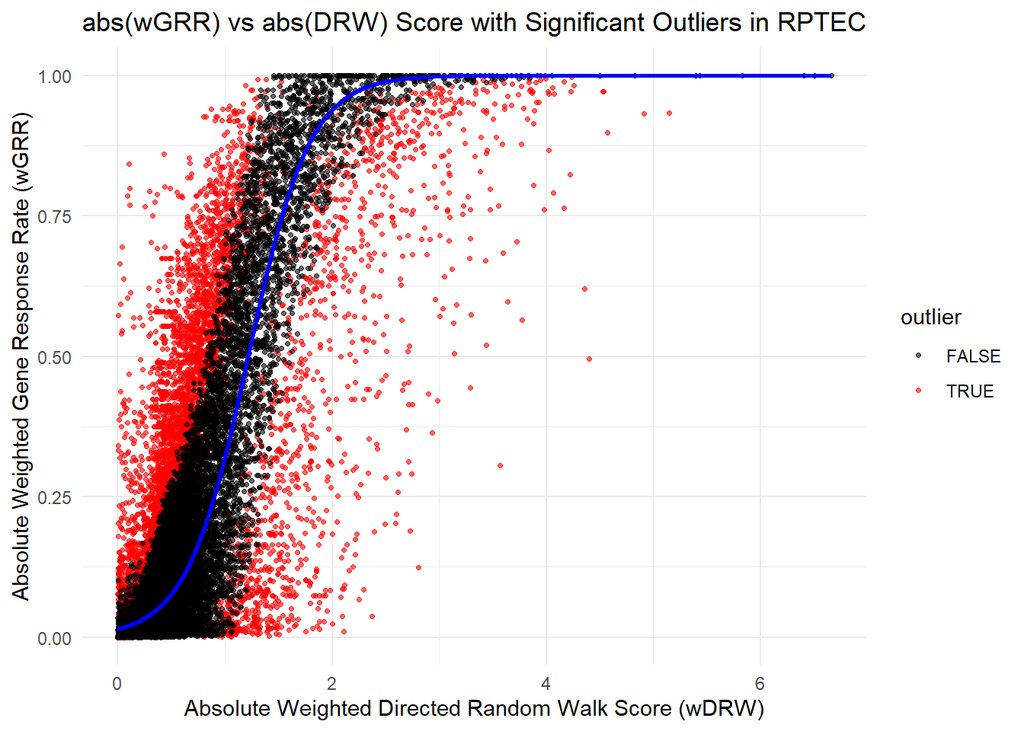

```r
ggplot(GRR_glm_fit_df, aes(x = abs(drw_zscore), y = abs(wGRR))) +
  geom_point(aes(color = outlier), alpha = 0.6, size = 0.9) +
  geom_line(aes(y = fitted_wGRR), color = "blue", size = 1) +
  scale_color_manual(values = c("black", "red")) +
  theme_minimal() +
  labs(
    title = "abs(wGRR) vs abs(DRW) Score with Significant Outliers in RPTEC",
    x = "Absolute Weighted Directed Random Walk Score (wDRW)",
    y = "Absolute Weighted Gene Response Rate (wGRR)"
  )
```

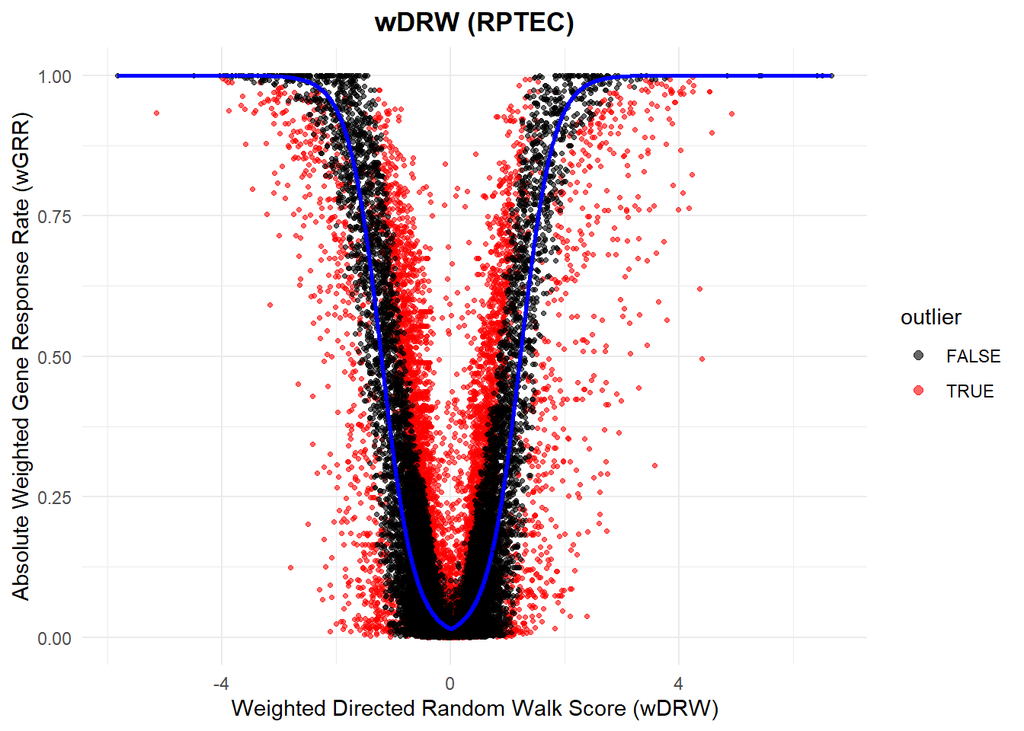

```r
ggplot(GRR_glm_fit_df, aes(x = drw_zscore, y = abs(wGRR))) +
  geom_point(aes(color = outlier), alpha = 0.6, size = 0.9) +
  geom_line(aes(y = fitted_wGRR), color = "blue", size = 1) +
  scale_color_manual(values = c("black", "red")) +
  theme_minimal() + theme(plot.title = element_text(hjust = 0.5, face = "bold")) +
  guides(color = guide_legend(override.aes = list(size = 2))) +
  labs(
    title = "wDRW (RPTEC)",
    x = "Weighted Directed Random Walk Score (wDRW)",
    y = "Absolute Weighted Gene Response Rate (wGRR)"
  )
```

## Modules and conditions with most significant outliers’

Based on the binomial GLM fit, we will now find the modules and conditions with the most significant outliers. Total, above and below the fit.

```r
significant_outliers_filtered <- GRR_glm_fit_df %>%
  filter(outlier)
```

```r
outliers_per_module <- significant_outliers_filtered %>%
  dplyr::count(module_number, sort = TRUE)
```

```r
outliers_per_sample <- significant_outliers_filtered %>%
  dplyr::count(sample_id, sort = TRUE)
```

```r
head(outliers_per_module, 10) # Top modules with outliers
```

```
## # A tibble: 10 × 2
##    module_number     n
##            <dbl> <int>
##  1             8   244
##  2             3   224
##  3             1   222
##  4             4   216
##  5             2   212
##  6             6   212
##  7             7   206
##  8             5   205
##  9             9   199
## 10            17   107
```

```r
head(outliers_per_sample, 10) # Top cconditions with outliers
```

```
## # A tibble: 10 × 2
##    sample_id                                       n
##    <chr>                                       <int>
##  1 LU_HRPTECTERT1_SINGLE_OMEPRAZOL_T3_C3         100
##  2 LU_HRPTECTERT1_SINGLE_MITOMYCINC_T3_C3         90
##  3 LU_HRPTECTERT1_SINGLE_ZOLENDRONICACID_T3_C3    89
##  4 LU_HRPTECTERT1_SINGLE_AMPHOTERICINB_T3_C1      87
##  5 LU_HRPTECTERT1_SINGLE_LEADACETATE_T3_C2        87
##  6 LU_HRPTECTERT1_SINGLE_OCHRATOXINA_T2_C1        87
##  7 LU_HRPTECTERT1_SINGLE_AMPHOTERICINB_T2_C2      84
##  8 LU_HRPTECTERT1_SINGLE_DOXORUBICIN_T3_C3        84
##  9 LU_HRPTECTERT1_SINGLE_MITOMYCINC_T3_C1         83
## 10 LU_HRPTECTERT1_SINGLE_MITOMYCINC_T3_C2         82
```

Interestingly, other modules and conditions are now found to be the top outliers than the ones found by the eigengene score analysis.

### Outliers per module: total, below and above the fit with human annotation

Here, we will visualize the modules with the most outliers. Total, below and above the Binomial GLM fit.

#### Total outliers from the GLM fit

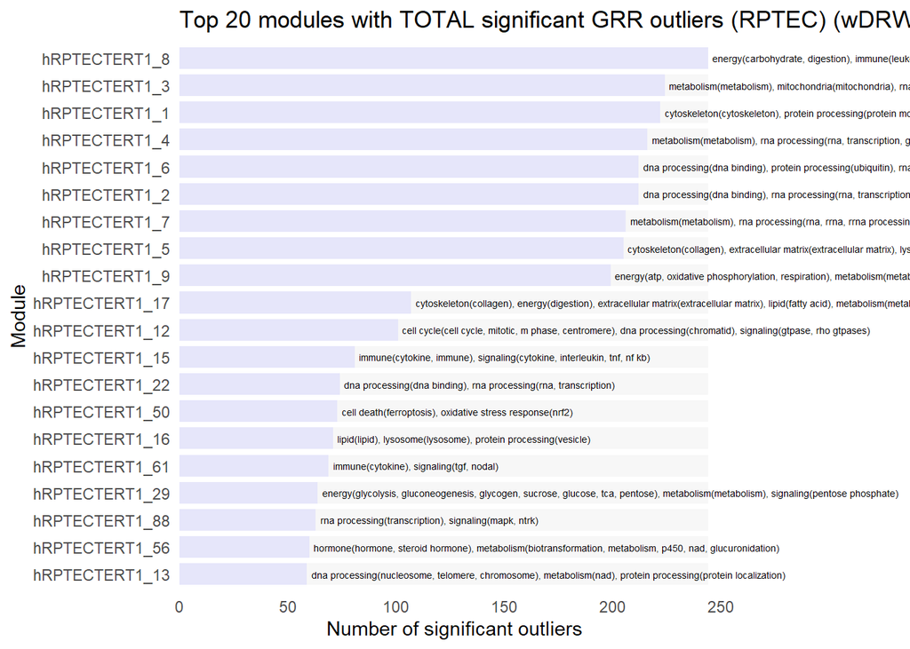

```r
threshold <- 300  # Same threshold

GRR_glm_fit_df %>%
  filter(outlier) %>%
  dplyr::count(module, annotation, sort = TRUE) %>%
  slice_max(n, n = 20, with_ties = FALSE) %>%
  mutate(
    max_n = max(n),
    hjust_val = ifelse(n < threshold, 0, 1.1),
    label_pos = ifelse(n < threshold, n + 2, n - 2)
  ) %>%
  ggplot(aes(x = reorder(module, n))) +
  geom_col(aes(y = max_n), fill = "grey97", width = 0.8) +
  geom_col(aes(y = n), fill = "lavender", width = 0.8) +
  geom_text(
    aes(y = label_pos, label = annotation, hjust = hjust_val),
    size = 1.8, color = "black"
  ) +
  coord_flip(clip = "off") +
  scale_y_continuous(
    limits = c(0, max(GRR_glm_fit_df %>%
      filter(outlier) %>%
      dplyr::count(module) %>%
      slice_max(n, n = 20, with_ties = FALSE) %>%
      pull(n)) + 10),
    expand = c(0, 0)
  ) +
  theme_minimal() +
  theme(
    plot.margin = margin(5.5, 100, 5.5, 5.5),
    panel.grid.major = element_blank(),
    panel.grid.minor = element_blank()
  ) +
  labs(
    title = "Top 20 modules with TOTAL significant GRR outliers (RPTEC) (wDRW)",
    x = "Module",
    y = "Number of significant outliers"
  )
```

#### Outliers above the GLM fit

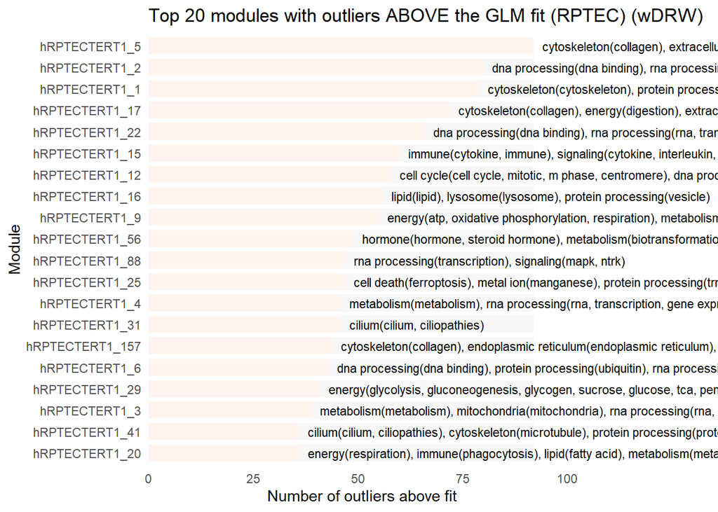

```r
threshold <- 300  # Threshold for switching annotation position

GRR_glm_fit_df %>%
  filter(outlier_direction == "Above fit") %>%
  dplyr::count(module, annotation, sort = TRUE) %>%
  slice_max(n, n = 20, with_ties = FALSE) %>%
  mutate(
    max_n = max(n),
    hjust_val = ifelse(n < threshold, 0, 1.1),
    label_pos = ifelse(n < threshold, n + 2, n - 2)
  ) %>%
  ggplot(aes(x = reorder(module, n))) +
  geom_col(aes(y = max_n), fill = "grey97", width = 0.8) +
  geom_col(aes(y = n), fill = "seashell", width = 0.8) +
  geom_text(
    aes(y = label_pos, label = annotation, hjust = hjust_val),
    size = 3, color = "black"
  ) +
  coord_flip(clip = "off") +
  scale_y_continuous(
    limits = c(0, max(GRR_glm_fit_df %>%
      filter(outlier_direction == "Above fit") %>%
      dplyr::count(module) %>%
      slice_max(n, n = 20, with_ties = FALSE) %>%
      pull(n)) + 10),
    expand = c(0, 0)
  ) +
  theme_minimal() +
  theme(
    plot.margin = margin(5.5, 100, 5.5, 5.5),
    panel.grid.major = element_blank(),
    panel.grid.minor = element_blank()
  ) +
  labs(
    title = "Top 20 modules with outliers ABOVE the GLM fit (RPTEC) (wDRW)",
    x = "Module",
    y = "Number of outliers above fit"
  )
```

#### Outliers below the GLM fit

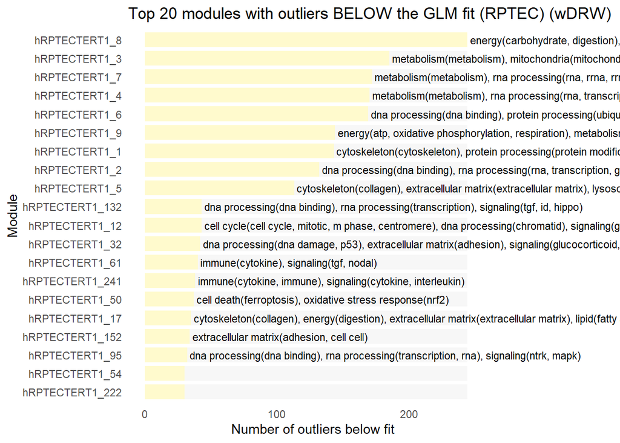

```r
threshold <- 400  # Threshold for annotation in plot

GRR_glm_fit_df %>%
  filter(outlier_direction == "Below fit") %>%
  dplyr::count(module, annotation, sort = TRUE) %>%
  slice_max(n, n = 20, with_ties = FALSE) %>%
  mutate(
    max_n = max(n),
    hjust_val = ifelse(n < threshold, 0, 1.1),       # outside or inside
    label_pos = ifelse(n < threshold, n + 2, n - 2)  # offset label position
  ) %>%
  ggplot(aes(x = reorder(module, n))) +

  # Background bar
  geom_col(aes(y = max_n), fill = "grey97", width = 0.8) +

  # Foreground bar (actual value)
  geom_col(aes(y = n), fill = "lemonchiffon", width = 0.8) +

  # Smart annotation positioning
  geom_text(
    aes(y = label_pos, label = annotation, hjust = hjust_val),
    size = 3, color = "black"
  ) +

  coord_flip(clip = "off") +  # Flip axes for horizontal bars

  # Y-axis limits: no exessive white space
  scale_y_continuous(limits = c(0, max(GRR_glm_fit_df %>%
    filter(outlier_direction == "Below fit") %>%
    dplyr::count(module) %>%
    slice_max(n, n = 20, with_ties = FALSE) %>%
    pull(n)) + 10)) +

  theme_minimal() +
  theme(
    plot.margin = margin(5.5, 100, 5.5, 5.5),
    panel.grid.major = element_blank(),
    panel.grid.minor = element_blank()
  ) +
  labs(
    title = "Top 20 modules with outliers BELOW the GLM fit (RPTEC) (wDRW)",
    x = "Module",
    y = "Number of outliers below fit"
  )
```

### Outliers per sample: above, below and total.

Now, we will assess what conditions have the most outliers. Total, below and above the binomial GLM fit.

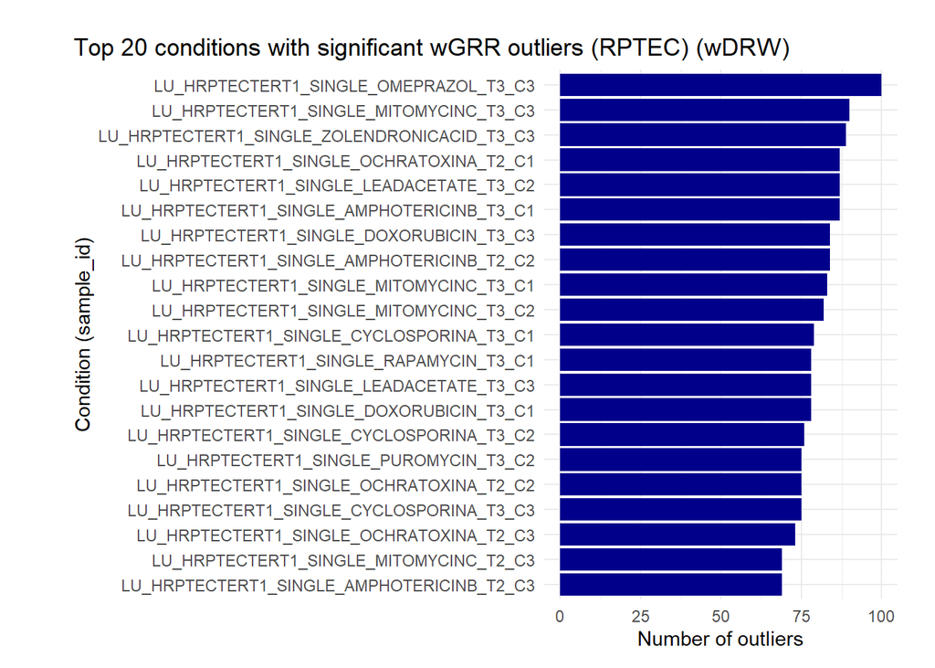

```r
outliers_per_sample %>%
  top_n(20, n) %>%
  ggplot(aes(x = reorder(sample_id, n), y = n)) +
  geom_col(fill = "darkblue") +
  coord_flip() +
  theme_minimal() +
  ggtitle("Top 20 conditions with significant wGRR outliers (RPTEC) (wDRW)") +
  theme(
    plot.title.position = "plot",
    plot.title = element_text(hjust = 0),
    plot.margin = margin(20, 20, 10, 40) # top, right, bottom, left
  ) +
  labs(
    x = "Condition (sample_id)",
    y = "Number of outliers"
  )
```

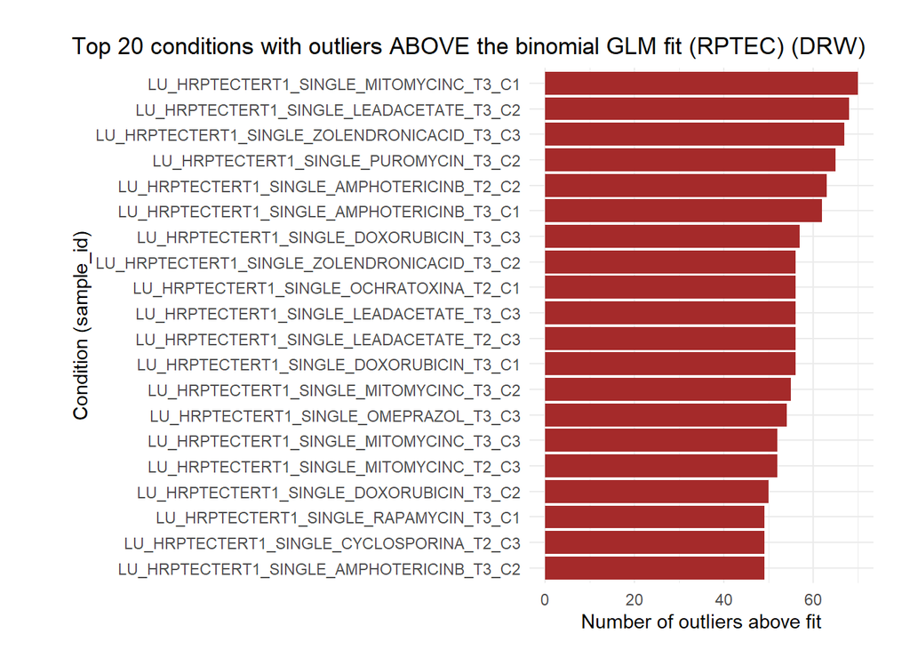

```r
GRR_glm_fit_df %>%
  filter(outlier_direction == "Above fit") %>%
  dplyr::count(sample_id, sort = TRUE) %>%
  top_n(20, n) %>%
  ggplot(aes(x = reorder(sample_id, n), y = n)) +
  geom_col(fill = "brown") +
  coord_flip() +
  theme_minimal() +
  ggtitle("Top 20 conditions with outliers ABOVE the binomial GLM fit (RPTEC) (DRW)") +
  theme(
    plot.title.position = "plot",
    plot.title = element_text(hjust = 0),
    plot.margin = margin(20, 20, 10, 40)
  ) +
  labs(
    x = "Condition (sample_id)",
    y = "Number of outliers above fit"
  )
```

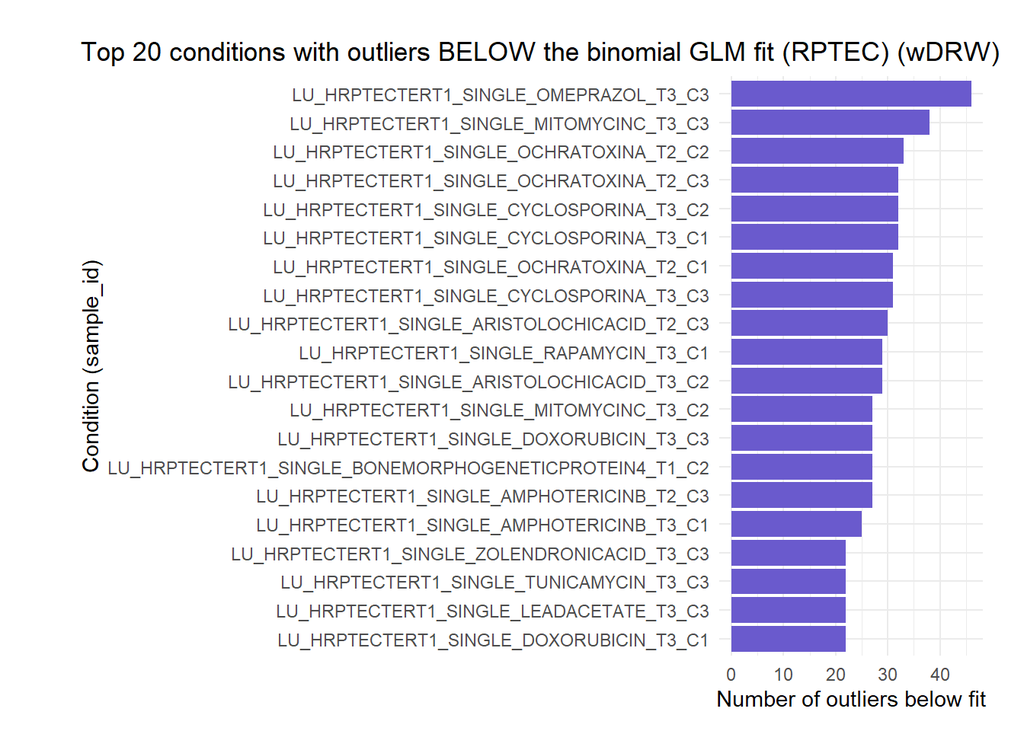

```r
GRR_glm_fit_df %>%
  filter(outlier_direction == "Below fit") %>%
  dplyr::count(sample_id, sort = TRUE) %>%
  slice_max(n, n = 20, with_ties = FALSE) %>%
  ggplot(aes(x = reorder(sample_id, n), y = n)) +
  geom_col(fill = "slateblue") +
  coord_flip() +
  theme_minimal() +
  ggtitle("Top 20 conditions with outliers BELOW the binomial GLM fit (RPTEC) (wDRW)") +
  theme(
    plot.title.position = "plot",
    plot.title = element_text(hjust = 0),
    plot.margin = margin(20, 20, 10, 40)
  ) +
  labs(
    x = "Condition (sample_id)",
    y = "Number of outliers below fit"
  )
```

# Conclusion

The DRW shows less outliers and a more ‘robust’ fit than the EG score on both the GRR and wGRR metric in RPTEC. It will be further assessed using other evaluations if the wDRW is better on other metrics as well.